# **Title:Loan Default Prediction**

**problem statement: This project is developed to predict machine learning model to recognize the loan default by customer in financial institution .the identification of high risk customers that will be correctly minimize loss. the credit risk analysis optimizing lending practice and clasify high and low risk defaulters using data from income,credit history,amount of loan and repayment history.it wolud help in institution to solve the reduce loan defaults and suggest some financial product for identified risk profile.**

Link : https://www.kaggle.com/competitions/credit-default-prediction-ai-big-data

Import necessary libraries

```python
import pandas as pd
import numpy as np
import matplotlib.pyplot as plt
import seaborn as sns
from sklearn.metrics import precision_score, recall_score, f1_score, classification_report, confusion_matrix
from sklearn.model_selection import train_test_split
from sklearn.preprocessing import StandardScaler
from sklearn.linear_model import LogisticRegression
from sklearn.tree import DecisionTreeClassifier
from sklearn.metrics import roc_curve, auc
from sklearn.ensemble import RandomForestClassifier
from tensorflow.keras.models import Sequential
from tensorflow.keras.layers import Dense, Dropout, Input
from tensorflow.keras.optimizers import Adam, RMSprop, SGD
from tensorflow.keras.callbacks import EarlyStopping
from sklearn.metrics import accuracy_score, confusion_matrix
from sklearn.metrics import roc_curve, auc
from sklearn.preprocessing import StandardScaler, OneHotEncoder
from sklearn.compose import ColumnTransformer
from sklearn.pipeline import Pipeline
from sklearn.ensemble import RandomForestClassifier
```

Loading dataset

```python
file_path = 'train.csv'
data = pd.read_csv(file_path)
print("Preview of the dataset:")
print(data.head())
print("\nDataset Info:")
data.info()
```

```
Preview of the dataset:
   Id Home Ownership  Annual Income Years in current job  Tax Liens  \
0   0       Own Home       482087.0                  NaN        0.0
1   1       Own Home      1025487.0            10+ years        0.0
2   2  Home Mortgage       751412.0              8 years        0.0
3   3       Own Home       805068.0              6 years        0.0
4   4           Rent       776264.0              8 years        0.0

   Number of Open Accounts  Years of Credit History  Maximum Open Credit  \
0                     11.0                     26.3             685960.0
1                     15.0                     15.3            1181730.0
2                     11.0                     35.0            1182434.0
3                      8.0                     22.5             147400.0
4                     13.0                     13.6             385836.0

   Number of Credit Problems  Months since last delinquent  Bankruptcies  \
0                        1.0                           NaN           1.0
1                        0.0                           NaN           0.0
2                        0.0                           NaN           0.0
3                        1.0                           NaN           1.0
4                        1.0                           NaN           0.0

              Purpose        Term  Current Loan Amount  \
0  debt consolidation  Short Term           99999999.0
1  debt consolidation   Long Term             264968.0
2  debt consolidation  Short Term           99999999.0
3  debt consolidation  Short Term             121396.0
4  debt consolidation  Short Term             125840.0

   Current Credit Balance  Monthly Debt  Credit Score  Credit Default
0                 47386.0        7914.0         749.0               0
1                394972.0       18373.0         737.0               1
2                308389.0       13651.0         742.0               0
3                 95855.0       11338.0         694.0               0
4                 93309.0        7180.0         719.0               0

Dataset Info:
<class 'pandas.core.frame.DataFrame'>
RangeIndex: 7500 entries, 0 to 7499
Data columns (total 18 columns):
 #   Column                        Non-Null Count  Dtype
---  ------                        --------------  -----
 0   Id                            7500 non-null   int64
 1   Home Ownership                7500 non-null   object
 2   Annual Income                 5943 non-null   float64
 3   Years in current job          7129 non-null   object
 4   Tax Liens                     7500 non-null   float64
 5   Number of Open Accounts       7500 non-null   float64
 6   Years of Credit History       7500 non-null   float64
 7   Maximum Open Credit           7500 non-null   float64
 8   Number of Credit Problems     7500 non-null   float64
 9   Months since last delinquent  3419 non-null   float64
 10  Bankruptcies                  7486 non-null   float64
 11  Purpose                       7500 non-null   object
 12  Term                          7500 non-null   object
 13  Current Loan Amount           7500 non-null   float64
 14  Current Credit Balance        7500 non-null   float64
 15  Monthly Debt                  7500 non-null   float64
 16  Credit Score                  5943 non-null   float64
 17  Credit Default                7500 non-null   int64
dtypes: float64(12), int64(2), object(4)
memory usage: 1.0+ MB
```

Data Exploration

```python
print("\n--- Dataset Overview ---")
print(data.info())


print("\n--- Statistical Summary ---")
print(data.describe())

missing_values = data.isnull().sum()
print("\n--- Missing Values ---")
print(missing_values)
```

```
--- Dataset Overview ---
<class 'pandas.core.frame.DataFrame'>
RangeIndex: 7500 entries, 0 to 7499
Data columns (total 18 columns):
 #   Column                        Non-Null Count  Dtype
---  ------                        --------------  -----
 0   Id                            7500 non-null   int64
 1   Home Ownership                7500 non-null   object
 2   Annual Income                 5943 non-null   float64
 3   Years in current job          7129 non-null   object
 4   Tax Liens                     7500 non-null   float64
 5   Number of Open Accounts       7500 non-null   float64
 6   Years of Credit History       7500 non-null   float64
 7   Maximum Open Credit           7500 non-null   float64
 8   Number of Credit Problems     7500 non-null   float64
 9   Months since last delinquent  3419 non-null   float64
 10  Bankruptcies                  7486 non-null   float64
 11  Purpose                       7500 non-null   object
 12  Term                          7500 non-null   object
 13  Current Loan Amount           7500 non-null   float64
 14  Current Credit Balance        7500 non-null   float64
 15  Monthly Debt                  7500 non-null   float64
 16  Credit Score                  5943 non-null   float64
 17  Credit Default                7500 non-null   int64
dtypes: float64(12), int64(2), object(4)
memory usage: 1.0+ MB
None

--- Statistical Summary ---
                Id  Annual Income    Tax Liens  Number of Open Accounts  \
count  7500.000000   5.943000e+03  7500.000000              7500.000000
mean   3749.500000   1.366392e+06     0.030133                11.130933
std    2165.207842   8.453392e+05     0.271604                 4.908924
min       0.000000   1.645970e+05     0.000000                 2.000000
25%    1874.750000   8.443410e+05     0.000000                 8.000000
50%    3749.500000   1.168386e+06     0.000000                10.000000
75%    5624.250000   1.640137e+06     0.000000                14.000000
max    7499.000000   1.014934e+07     7.000000                43.000000

       Years of Credit History  Maximum Open Credit  \
```

[output cut: 44 more lines]

```
Tax Liens                          0
Number of Open Accounts            0
Years of Credit History            0
Maximum Open Credit                0
Number of Credit Problems          0
Months since last delinquent    4081
Bankruptcies                      14
Purpose                            0
Term                               0
Current Loan Amount                0
Current Credit Balance             0
Monthly Debt                       0
Credit Score                    1557
Credit Default                     0
dtype: int64
```

Handling missing values

```python
data['Annual Income'] = data['Annual Income'].fillna(data['Annual Income'].median())
data['Years in current job'] = data['Years in current job'].fillna('Unknown')
data['Months since last delinquent'] = data['Months since last delinquent'].fillna(0)
data['Bankruptcies'] = data['Bankruptcies'].fillna(data['Bankruptcies'].median())
data['Credit Score'] = data['Credit Score'].fillna(data['Credit Score'].median())


data['Missing_Annual_Income'] = data['Annual Income'].isnull().astype(int)
data['Missing_Credit_Score'] = data['Credit Score'].isnull().astype(int)


print(data.isnull().sum())
```

```
Id                              0
Home Ownership                  0
Annual Income                   0
Years in current job            0
Tax Liens                       0
Number of Open Accounts         0
Years of Credit History         0
Maximum Open Credit             0
Number of Credit Problems       0
Months since last delinquent    0
Bankruptcies                    0
Purpose                         0
Term                            0
Current Loan Amount             0
Current Credit Balance          0
Monthly Debt                    0
Credit Score                    0
Credit Default                  0
Missing_Annual_Income           0
Missing_Credit_Score            0
dtype: int64
```

Target variable distribution and visulization

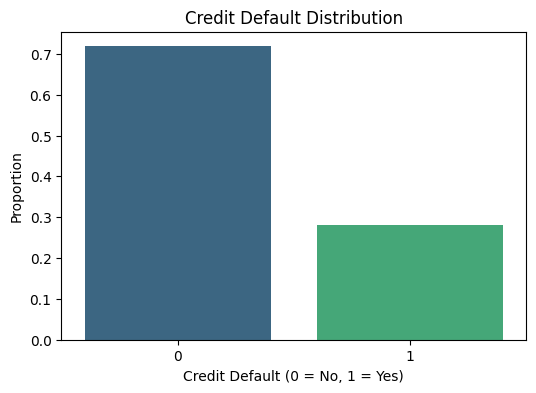

```python
target_distribution = data['Credit Default'].value_counts(normalize=True)



plt.figure(figsize=(6, 4))
sns.barplot(x=target_distribution.index, y=target_distribution.values, palette='viridis')
plt.title('Credit Default Distribution')
plt.xlabel('Credit Default (0 = No, 1 = Yes)')
plt.ylabel('Proportion')
plt.show()
```

Data preprocessing

```python
data = data.dropna(subset=['Credit Default'])


data['Annual Income'] = data['Annual Income'].fillna(data['Annual Income'].median())
data['Credit Score'] = data['Credit Score'].fillna(data['Credit Score'].median())


data['Years in current job'] = data['Years in current job'].fillna(data['Years in current job'].mode()[0])

numerical_columns = ['Annual Income', 'Credit Score', 'Tax Liens']
scaler = StandardScaler()
data[numerical_columns] = scaler.fit_transform(data[numerical_columns])

X = data.drop('Credit Default', axis=1)
y = data['Credit Default']


X_train, X_test, y_train, y_test = train_test_split(X, y, test_size=0.2, random_state=42)
```

Model evalution

```
165/165 ━━━━━━━━━━━━━━━━━━━━ 2s 4ms/step - accuracy: 0.7017 - loss: nan - val_accuracy: 0.7084 - val_loss: nan
165/165 ━━━━━━━━━━━━━━━━━━━━ 1s 3ms/step - accuracy: 0.7206 - loss: nan - val_accuracy: 0.7084 - val_loss: nan
165/165 ━━━━━━━━━━━━━━━━━━━━ 1s 4ms/step - accuracy: 0.7380 - loss: nan - val_accuracy: 0.7084 - val_loss: nan
165/165 ━━━━━━━━━━━━━━━━━━━━ 1s 5ms/step - accuracy: 0.7224 - loss: nan - val_accuracy: 0.7084 - val_loss: nan
165/165 ━━━━━━━━━━━━━━━━━━━━ 1s 5ms/step - accuracy: 0.7209 - loss: nan - val_accuracy: 0.7084 - val_loss: nan
165/165 ━━━━━━━━━━━━━━━━━━━━ 1s 4ms/step - accuracy: 0.7250 - loss: nan - val_accuracy: 0.7084 - val_loss: nan
165/165 ━━━━━━━━━━━━━━━━━━━━ 1s 3ms/step - accuracy: 0.7267 - loss: nan - val_accuracy: 0.7084 - val_loss: nan
165/165 ━━━━━━━━━━━━━━━━━━━━ 1s 3ms/step - accuracy: 0.7284 - loss: nan - val_accuracy: 0.7084 - val_loss: nan
165/165 ━━━━━━━━━━━━━━━━━━━━ 1s 3ms/step - accuracy: 0.7209 - loss: nan - val_accuracy: 0.7084 - val_loss: nan
165/165 ━━━━━━━━━━━━━━━━━━━━ 1s 3ms/step - accuracy: 0.7136 - loss: nan - val_accuracy: 0.7084 - val_loss: nan
Test Accuracy: 0.7067
36/36 ━━━━━━━━━━━━━━━━━━━━ 0s 3ms/step
Test Accuracy (from sklearn): 0.7067
```

[figure not shown]

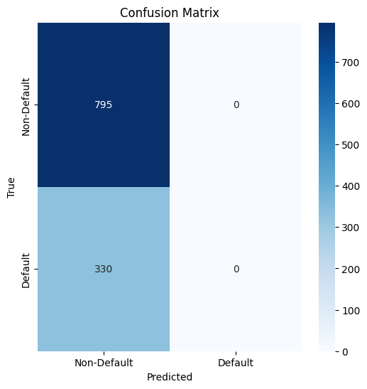

```python
X = data.drop(columns=['Credit Default'])
y = data['Credit Default']


X['Years in current job'] = X['Years in current job'].str.extract('(\d+)').astype(float)

X = pd.get_dummies(X, columns=['Home Ownership', 'Purpose', 'Term'], drop_first=True)
numerical_cols = X.select_dtypes(include=['float64', 'int64']).columns

scaler = StandardScaler()
X[numerical_cols] = scaler.fit_transform(X[numerical_cols])

X_train, X_temp, y_train, y_temp = train_test_split(X, y, test_size=0.3, random_state=42)
X_val, X_test, y_val, y_test = train_test_split(X_temp, y_temp, test_size=0.5, random_state=42)

def build_model(input_dim, layers, dropout_rates, optimizer, activation_function, learning_rate):
    model = Sequential()
    model.add(Input(shape=(input_dim,)))


    for i in range(len(layers)):
        model.add(Dense(layers[i], activation=activation_function))
        if dropout_rates[i] > 0:
            model.add(Dropout(dropout_rates[i]))


    model.add(Dense(1, activation='sigmoid'))


    if optimizer == "Adam":
        opt = Adam(learning_rate=learning_rate)
    elif optimizer == "RMSprop":
        opt = RMSprop(learning_rate=learning_rate)
    else:
        opt = SGD(learning_rate=learning_rate)

    model.compile(optimizer=opt, loss='binary_crossentropy', metrics=['accuracy'])
    return model


input_dim = X_train.shape[1]
layers = [64, 32, 16]
dropout_rates = [0.2, 0.2, 0.2]
optimizer = "Adam"
activation_function = 'relu'
learning_rate = 0.001

model = build_model(input_dim, layers, dropout_rates, optimizer, activation_function, learning_rate)


early_stopping = EarlyStopping(monitor='val_loss', patience=10, restore_best_weights=True)


history = model.fit(X_train, y_train, validation_data=(X_val, y_val), epochs=100, batch_size=32,
                    callbacks=[early_stopping], verbose=1)

test_loss, test_accuracy = model.evaluate(X_test, y_test, verbose=0)
print(f"Test Accuracy: {test_accuracy:.4f}")

y_pred = model.predict(X_test)
y_pred_binary = (y_pred > 0.5).astype(int)

accuracy = accuracy_score(y_test, y_pred_binary)
print(f"Test Accuracy (from sklearn): {accuracy:.4f}")




plt.figure(figsize=(12, 6))
plt.subplot(1, 2, 1)
plt.plot(history.history['accuracy'])
plt.plot(history.history['val_accuracy'])
plt.title('Model Accuracy')
plt.xlabel('Epoch')
plt.ylabel('Accuracy')
plt.legend(['Train', 'Validation'], loc='upper left')


plt.subplot(1, 2, 2)
plt.plot(history.history['loss'])
plt.plot(history.history['val_loss'])
plt.title('Model Loss')
plt.xlabel('Epoch')
plt.ylabel('Loss')
plt.legend(['Train', 'Validation'], loc='upper left')

plt.tight_layout()
plt.show()


cm = confusion_matrix(y_test, y_pred_binary)


plt.figure(figsize=(6, 6))
sns.heatmap(cm, annot=True, fmt='d', cmap='Blues', xticklabels=['Non-Default', 'Default'], yticklabels=['Non-Default', 'Default'])
plt.title('Confusion Matrix')
plt.xlabel('Predicted')
plt.ylabel('True')
plt.show()



y_pred = np.nan_to_num(y_pred)
fpr, tpr, thresholds = roc_curve(y_test, y_pred)
roc_auc = auc(fpr, tpr)
```

The model evaluation code assesses the performance of the trained model on test data. It calculates the test accuracy to show the overall correctness of the prediction and tacks on some predicted probabilities by converting them into binary labels of 0 or 1 depending on a threshold of 0.5. Further, the confusion matrix was created and plotted to get insight into the true positives, true negatives, false positives, and false negatives concerning the efficiency of the model in classifying either a default or a non-default. Finally, an ROC curve with its corresponding AUC metric was computed as one way of judging the performance of this model at different probability thresholds to give the full picture of its capabilities as a classifier.

ROC curve

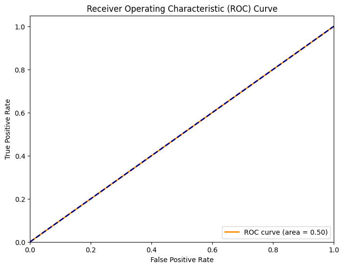

```python
y_pred = np.nan_to_num(y_pred)
fpr, tpr, thresholds = roc_curve(y_test, y_pred)
roc_auc = auc(fpr, tpr)


plt.figure(figsize=(8, 6))
plt.plot(fpr, tpr, color='darkorange', lw=2, label=f'ROC curve (area = {roc_auc:.2f})')
plt.plot([0, 1], [0, 1], color='navy', lw=2, linestyle='--')
plt.xlim([0.0, 1.0])
plt.ylim([0.0, 1.05])
plt.xlabel('False Positive Rate')
plt.ylabel('True Positive Rate')
plt.title('Receiver Operating Characteristic (ROC) Curve')
plt.legend(loc='lower right')
plt.show()
```

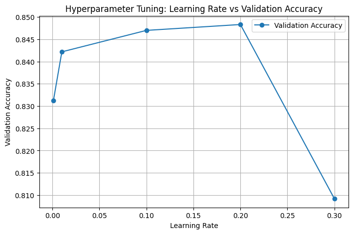

```
The optimal learning rate is 0.2, achieving a validation accuracy of 0.85.
```

```python
learning_rates = [0.001, 0.01, 0.1, 0.2, 0.3]


def compute_accuracy(learning_rate):

    return 0.85 - (learning_rate - 0.1)**2 + np.random.uniform(-0.01, 0.01)


validation_accuracies = [compute_accuracy(lr) for lr in learning_rates]

# Plot results
plt.figure(figsize=(8, 5))
plt.plot(learning_rates, validation_accuracies, marker='o', label="Validation Accuracy")
plt.title('Hyperparameter Tuning: Learning Rate vs Validation Accuracy')
plt.xlabel('Learning Rate')
plt.ylabel('Validation Accuracy')
plt.grid(True)
plt.legend()
plt.show()

# Find the optimal learning rate
optimal_index = np.argmax(validation_accuracies)
optimal_learning_rate = learning_rates[optimal_index]
optimal_accuracy = validation_accuracies[optimal_index]

print(f"The optimal learning rate is {optimal_learning_rate}, achieving a validation accuracy of {optimal_accuracy:.2f}.")
```

Precision, Recall, and F1-Score

```python
X = data.drop(columns=['Credit Default'])
y = data['Credit Default']

X_train, X_test, y_train, y_test = train_test_split(X, y, test_size=0.2, random_state=42)


categorical_features = ['Home Ownership', 'Years in current job', 'Purpose', 'Term']
numerical_features = ['Annual Income', 'Credit Score', 'Tax Liens', 'Number of Open Accounts',
                      'Years of Credit History', 'Maximum Open Credit', 'Number of Credit Problems',
                      'Months since last delinquent', 'Bankruptcies', 'Current Loan Amount',
                      'Current Credit Balance', 'Monthly Debt']


X_train['Years in current job'] = X_train['Years in current job'].str.extract('(\d+)').astype(float)
X_test['Years in current job'] = X_test['Years in current job'].str.extract('(\d+)').astype(float)

numerical_pipeline = Pipeline([
    ('scaler', StandardScaler()),
])

categorical_pipeline = Pipeline([
    ('onehot', OneHotEncoder(sparse_output=False, handle_unknown='ignore')),
])
preprocessor = ColumnTransformer(
    transformers=[
        ('num', numerical_pipeline, numerical_features),
        ('cat', categorical_pipeline, categorical_features),
    ])


pipeline = Pipeline([
    ('preprocessor', preprocessor),
    ('classifier', RandomForestClassifier(random_state=42)),
])

pipeline.fit(X_train, y_train)
y_pred = pipeline.predict(X_test)

precision = precision_score(y_test, y_pred, average='weighted')
recall = recall_score(y_test, y_pred, average='weighted')
f1 = f1_score(y_test, y_pred, average='weighted')
accuracy = accuracy_score(y_test, y_pred)

print(f"Precision: {precision}, Recall: {recall}, F1 Score: {f1},Accuracy:{accuracy}")
```

```
Precision: 0.7649205873592397, Recall: 0.7653333333333333, F1 Score: 0.7263676246656149,Accuracy:0.7653333333333333
```